# Example re-analysis of HAI (hemagglutination inhibition) data from one influenza vaccination study (SDY212) from ImmPort in R

## Introduction

In this tutorial we will show how to re-analyze the hemagglutination inhibition (HAI) assay data from one study in ImmPort using *R*.

The data stored in ImmPort can be viewed and accessed through [the web site](https://immport.niaid.nih.gov/). The database content is also available for download in MySQL and Tab Separated Value (TSV) files. To download data from ImmPort you must first register for a free account.

### The study

In ImmPort, each study has a study accession beginning with the letters SDY, followed by a number. For this example, we will focus on the study SDY212.

**Study accession** SDY212

**Title:** Apoptosis and other immune biomarkers predict influenza vaccine responsiveness

**Principal Investigator:** Mark M. Davis

**Description:** In an effort to identify benchmarks of immunological health, influenza vaccination was used in 30 young (20 to 30 years) and 59 older subjects (60 to 89 years) as models for strong and weak immune responses, respectively.

The data from this study can be downloaded [here](https://www.immport.org/shared/study/SDY212). If the page opens with an error, please make sure to log into ImmPort.

### Influenza hemagglutination inhibition assay

The hemagglutination inhibition (HAI) assay can be used to determine the level of antibodies to influenza virus in a serum sample.

### Influenza vaccine

Seasonal influenza vaccine contains antigens representing three (trivalent vaccine) or four (quadrivalent vaccine) influenza virus strains: * Influenza type A subtype H1N1 virus strain * Influenza type A subtype H3N2 virus strain * One or two influenza type B virus strains

### Seroprotection and seroconversion

A hemagglutination inhibition assay (HAI) antibody titer of 40 or more is generally associated with a 50% reduction in risk of influenza illness. The World Health Organization defines effective and seropositive influenza vaccine responses as a 28-day post-vaccine antibody HAI titer greater than or equal to 40. The seroprotection rate is defined as the proportion of participants with HAI titers of 40 or more.

Seroconversion/Seroresponders are defined as subjects with a fourfold or greater increase in antibody titer after vaccination. Consequently, the Seroconversion rate is the proportion of subjects with a fourfold or greater increase in HAI antibody titer after vaccination relative to pre-vaccination.

## Analysis

### Load *R* libraries used for this analysis.

Libraries that are not available yet in the *R* distribution need to be installed first. In the following commands, four required libraries are installed. Run these 4 commands if you do not have these packages installed.

install.packages(“scales”)  
install.packages(“ggplot2”)  
install.packages(“reshape”)  
install.packages(“RMySQL”)

The four libraries then need to be loaded as in the following code snippet.

```r
library(scales)
```

```r
library(ggplot2)
library(reshape)
library(RMySQL)
```

### Loading in the information from MySQL and merging the contents

The data we will be using for this tutorial is contained in the SDY212-DR14_MySQL.zip file.

An alternative to using the TSV files to analyze the study data in *R* is a MySQL database. At the moment, the ImmPort MySQL database can not be made publicly available to users not registered with ImmPort. In order to run this part of the code, a personal copy of the database needs to be installed. ImmPort provides the public MySQL database as one download containing the data of all studies or as separate download for each study. The queries in this section are developed to work with either of these options.

The table and column documentation for the public ImmPort database [schema](https://www.immport.org/shared/dataModelDocumentation?table=study) as well as the full [Data Model](https://www.immport.org/shared/dataModel) are available on the ImmPort web site.

The next step is to connect and authenticate to the MySQL database. The connection parameters need to be adjusted to connect to a personal installation of the ImmPort MySQL database. The object `con` is created that will be used to direct commands to the database engine.

```r
con <- dbConnect(MySQL(), user="user", password="password",dbname="dbname",host="host")
```

#### Query and format the study data

Query the required information about the subjects and the HAI assay results.

```r
hai.data.SDY212 <- dbGetQuery(con,"SELECT hr.subject_accession, hr.arm_accession, hr.study_time_collected, hr.study_time_collected_unit, hr.value_preferred, hr.virus_strain_reported, s.race, s.gender, a2s.min_subject_age, a2s.age_unit
    FROM hai_result hr, subject s, arm_2_subject a2s
                WHERE hr.study_accession = 'SDY212'
                AND hr.subject_accession = s.subject_accession
    AND a2s.subject_accession = s.subject_accession;")
hai.data.SDY212 <- cbind(hai.data.SDY212,ARM_NAME=NA)
hai.data.SDY212[which(hai.data.SDY212$arm_accession == "ARM894"),"ARM_NAME"] <- "Young"
hai.data.SDY212[which(hai.data.SDY212$arm_accession == "ARM895"),"ARM_NAME"] <- "Old"
```

Check if the age unit is the same for all subjects. It is uniquely ‘Years’ for all subjects in this study.

```r
unique(hai.data.SDY212[,"age_unit"])
```

```
## [1] "Years"
```

Build a data frame with subject information and separate columns for pre-vaccination HAI titer (Day 0), post-vaccination HAI titer (Day 28) and their fold change (post titer/pre titer).

```r
hai.SDY212.prepost <- cast(hai.data.SDY212, subject_accession + min_subject_age + gender + race + virus_strain_reported + arm_accession + ARM_NAME ~ study_time_collected, value='value_preferred')
colnames(hai.SDY212.prepost)[colnames(hai.SDY212.prepost)%in%c("0","28")] <- c("Day0","Day28")
hai.results.SDY212 <- cbind(hai.SDY212.prepost, fold.change= hai.SDY212.prepost[,"Day28"] / hai.SDY212.prepost[,"Day0"])
```

#### Format the data frame to be consistent with the data read in from TSV files

In order for this created data frame to be used for the later analysis steps (starting with the section *Explore the study data*) on the main page of this tutorial, the column names, expect ‘Day0’, ‘Day28’ and ‘fold.change’, need to be changed to upper case letters.

```r
colnames(hai.results.SDY212) <- sapply(colnames(hai.results.SDY212),function(x){
  if(x %in% c('Day0', 'Day28', 'fold.change')){
    return(x)
  }else{
    return(toupper(x))
  }})
```

### Explore the study data

When working with a new data set, it is usefull to get an overview of the data. Now that we built our data table, we will look first at the subject data. We show some descriptive statistics and some simple plots of the data, just to get a feel for the distribution of age, gender and race. Plotting is done using the ggplot2 package, which is based on the Grammar of Graphics (by Leland Wilkinson) to describe data graphics. A great page to learn about ggplot2 and as a look-up resource can be found in the [Cookbook for R](http://www.cookbook-r.com/Graphs/).

#### Table of subjects with HAI data

We should use the `hai.results.SDY212` table to explore the subject characteristics in this study. However, `hai.results.SDY212` contains three rows per subject, one for each virus strain. So, we create a new matrix containing only one row for each subject.

```r
subjects.HAI <- unique(hai.results.SDY212[,c("SUBJECT_ACCESSION", "MIN_SUBJECT_AGE", "GENDER", "RACE","ARM_NAME")])
```

#### Descriptive statistics

First, we get an overview of how many subjects per categorical variable (arm, gender, race) we have in our data set.

```r
table(subjects.HAI$ARM_NAME)
```

```
##
##   Old Young
##    60    29
```

```r
table(subjects.HAI$GENDER)
```

```
##
## Female   Male
##     54     35
```

```r
table(subjects.HAI$RACE)
```

```
##
## American Indian or Alaska Native                            Asian
##                                1                                8
##                            Other                            White
##                                7                               73
```

#### Chart descriptive statistics

As a second step, we create a few plots that show us the demographic data visually.

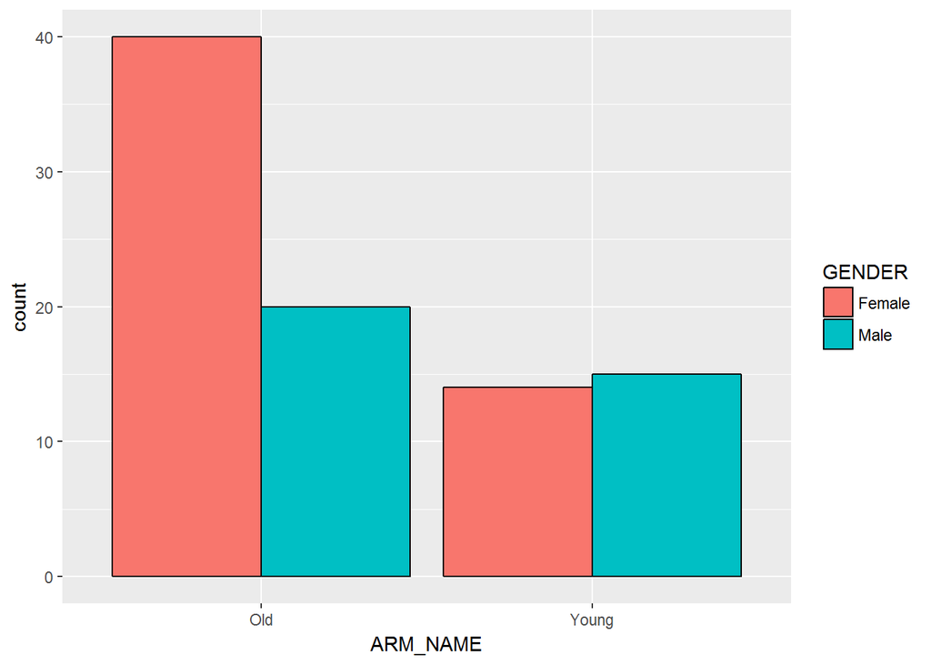

```r
ggplot(data=subjects.HAI, aes(x=ARM_NAME,fill=GENDER)) + geom_bar(stat="count", position=position_dodge(), colour="black")
```

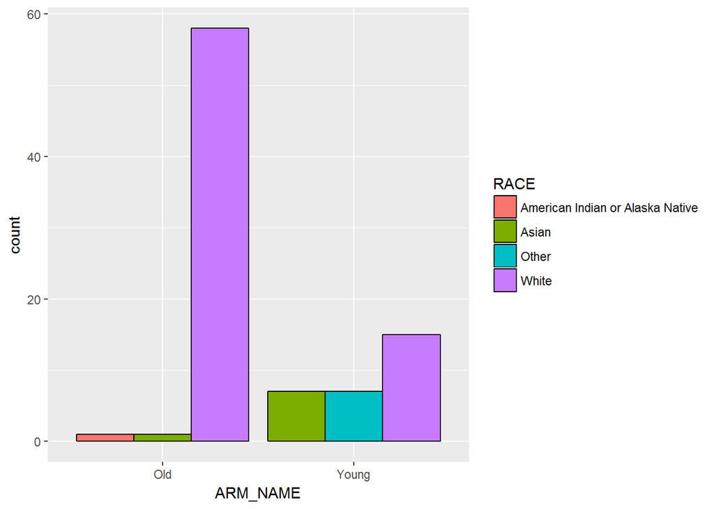

```r
ggplot(data=subjects.HAI, aes(x=ARM_NAME,fill=RACE)) + geom_bar(stat="count", position=position_dodge(), colour="black")
```

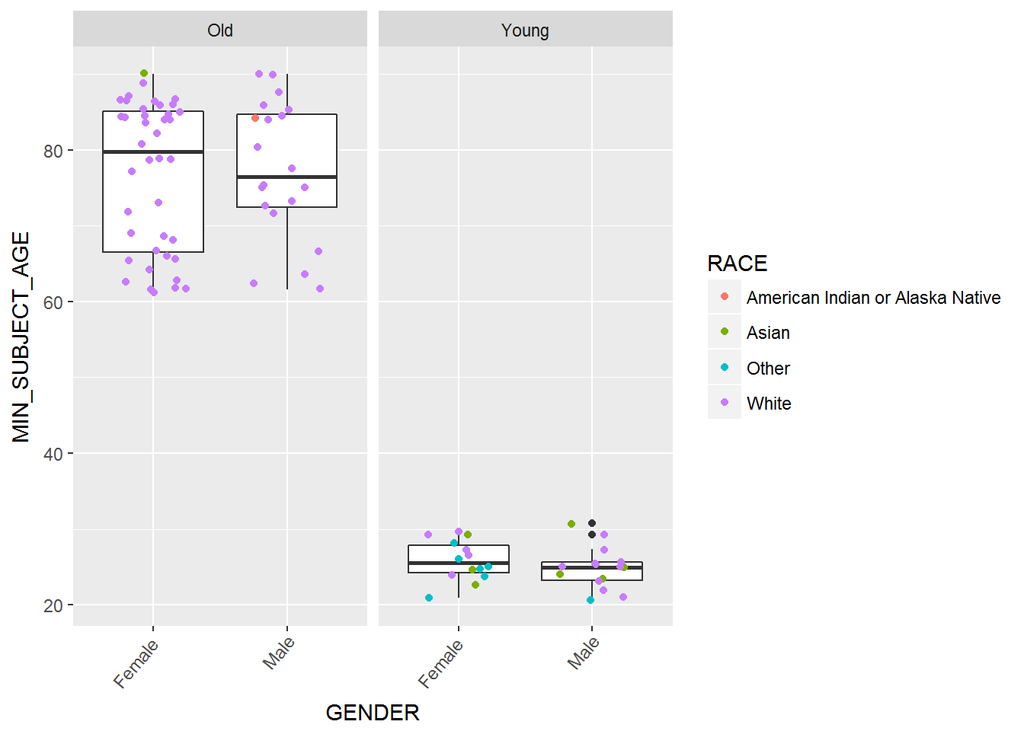

```r
ggplot(data=subjects.HAI, aes(x=GENDER,y=MIN_SUBJECT_AGE)) + geom_boxplot() + geom_point(aes(color=RACE),position=position_jitter(width=0.25,height=.1)) + theme(axis.text.x=element_text(angle=50, vjust=1.2,hjust=1.2)) + facet_wrap(~ ARM_NAME,ncol=2)
```

### Analyzing the HAI results

#### Initial plotting of data

Plot of post (Day 28) vs. pre (Day 0) vaccination HAI titer. Colored by virus strain.

This plot shows the typical triangular shape. If a subject already has a certain HAI titer for one strain before vaccination (x axis), it will most likely not go down after vaccination (y axis). This produces the triangular shape seen in this plot.

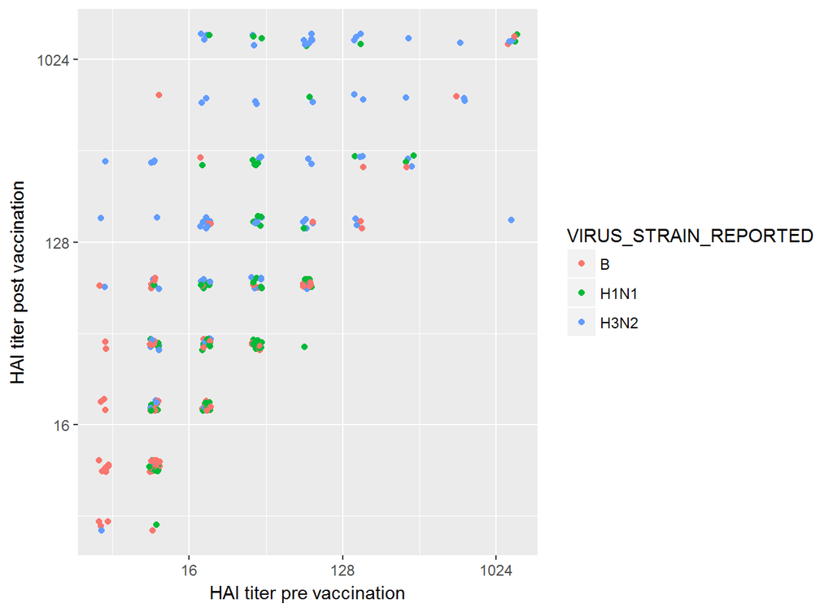

```r
ggplot(hai.results.SDY212, aes(x=Day0, y=Day28, color=VIRUS_STRAIN_REPORTED)) +
        scale_y_continuous(trans=log2_trans()) + scale_x_continuous(trans=log2_trans()) +
            geom_point(position=position_jitter(width=0.1,height=.1)) +
            ylab("HAI titer post vaccination") + xlab("HAI titer pre vaccination")
```

Plot of HAI response (fold change) vs. pre (Day 0) vaccination HAI titer.

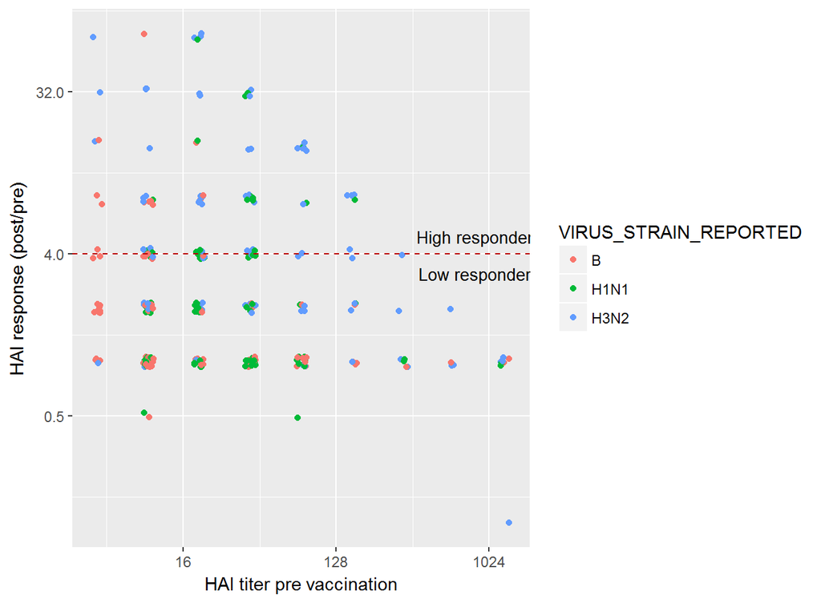

```r
ggplot(hai.results.SDY212, aes(x=Day0, y=fold.change, color=VIRUS_STRAIN_REPORTED)) +
        scale_y_continuous(trans=log2_trans()) + scale_x_continuous(trans=log2_trans()) +
            geom_point(position=position_jitter(width=0.1,height=.1)) +
            geom_hline(aes(yintercept=4), colour="#BB0000", linetype="dashed") +
            ylab("HAI response (post/pre)") + xlab("HAI titer pre vaccination") +
      annotate("text", label = "High responders", x = 900, y = 5, size = 3.5) + annotate("text", label = "Low responders", x = 900, y = 3.1, size = 3.5)
```

#### Examining if subject age and virus strain influence the influenza vaccine response

Plotting boxplots of the HAI responses by virus strain, we can see that the response varies by virus type.

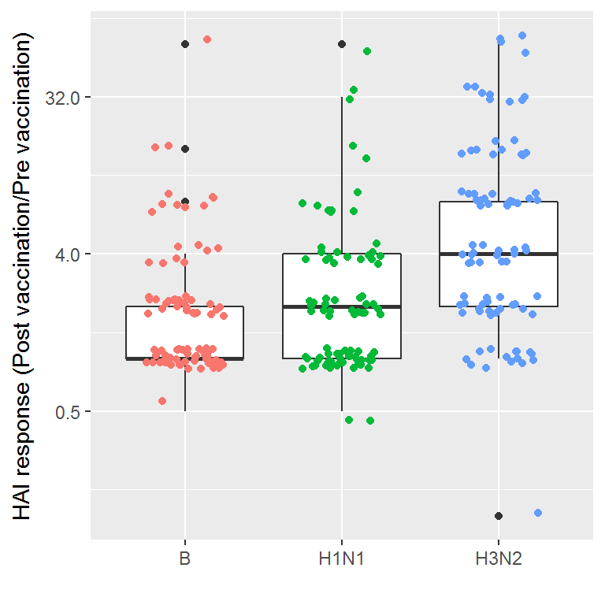

```r
ggplot(hai.results.SDY212, aes(x=VIRUS_STRAIN_REPORTED, y=fold.change)) + geom_boxplot() + xlab("") + theme(legend.position="none") + geom_point(aes(color=VIRUS_STRAIN_REPORTED),position=position_jitter(width=0.25,height=.2)) + scale_y_continuous(trans=log2_trans())+ ylab("HAI response (Post vaccination/Pre vaccination)")
```

Showing the response data per age group (arm) points to the idea that the HAI response also varies by arm.

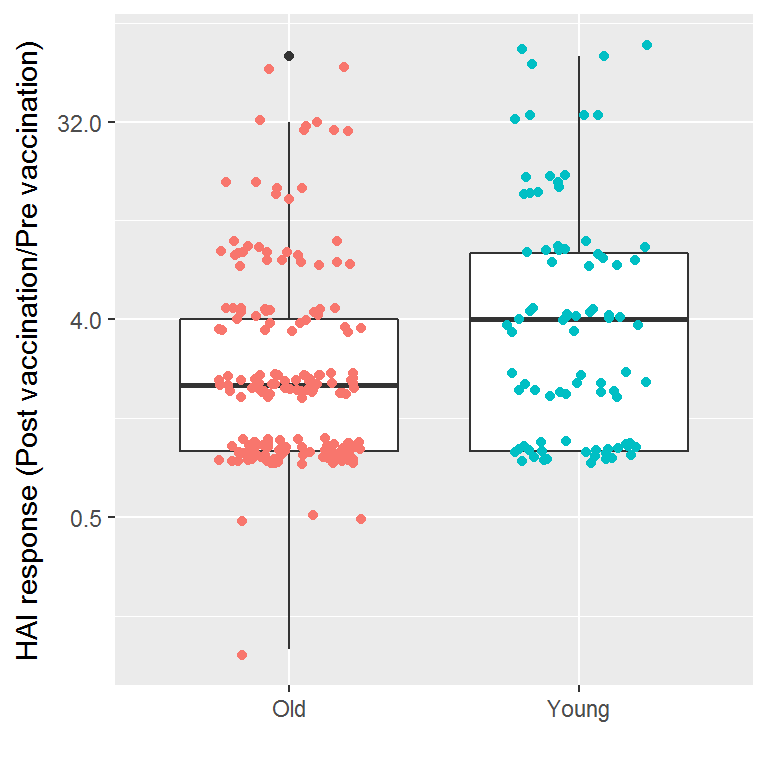

```r
ggplot(hai.results.SDY212, aes(x=ARM_NAME, y=fold.change)) + geom_boxplot() + xlab("") + theme(legend.position="none") + geom_point(aes(color=ARM_NAME),position=position_jitter(width=0.25,height=.2)) + scale_y_continuous(trans=log2_trans())+ ylab("HAI response (Post vaccination/Pre vaccination)")
```

Next, we focussed on the combination of these two factors. Do young people have a higher response for each of the three virus strains?

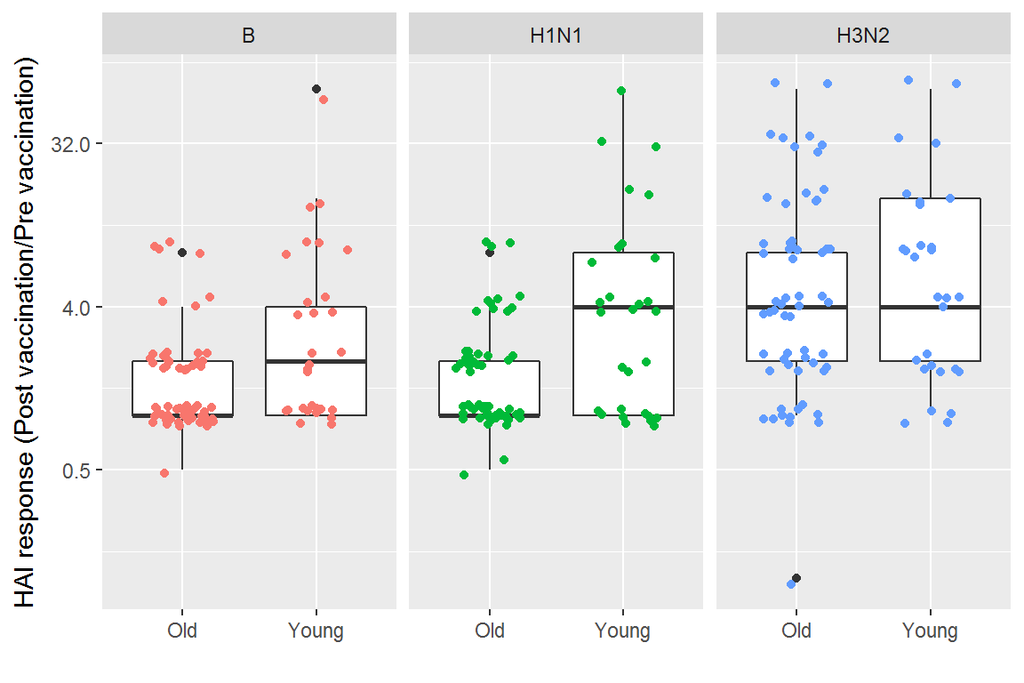

```r
ggplot(hai.results.SDY212, aes(x=ARM_NAME, y=fold.change)) + geom_boxplot() + xlab("") + theme(legend.position="none") + geom_point(aes(color=VIRUS_STRAIN_REPORTED),position=position_jitter(width=0.25,height=.2)) + scale_y_continuous(trans=log2_trans())+ ylab("HAI response (Post vaccination/Pre vaccination)") + facet_wrap(~ VIRUS_STRAIN_REPORTED)
```

In this figure, it appears that the response to the H3N2 strain is independent of age. However, for the H1N1 and B strains, younger subjects respond stronger than older subjects. To test this, we run Wilcoxon rank sum tests.

```r
wilcox.test(hai.results.SDY212[which(hai.results.SDY212[,"VIRUS_STRAIN_REPORTED"]=="B" & hai.results.SDY212[,"ARM_NAME"]=="Young"),"fold.change"],  hai.results.SDY212[which(hai.results.SDY212[,"VIRUS_STRAIN_REPORTED"]=="B" & hai.results.SDY212[,"ARM_NAME"]=="Old"),"fold.change"])
```

```
##
##  Wilcoxon rank sum test with continuity correction
##
## data:  hai.results.SDY212[which(hai.results.SDY212[, "VIRUS_STRAIN_REPORTED"] ==  and hai.results.SDY212[which(hai.results.SDY212[, "VIRUS_STRAIN_REPORTED"] ==     "B" & hai.results.SDY212[, "ARM_NAME"] == "Young"), "fold.change"] and     "B" & hai.results.SDY212[, "ARM_NAME"] == "Old"), "fold.ch…
## W = 1112, p-value = 0.02183
## alternative hypothesis: true location shift is not equal to 0
```

```r
wilcox.test(hai.results.SDY212[which(hai.results.SDY212[,"VIRUS_STRAIN_REPORTED"]=="H1N1" & hai.results.SDY212[,"ARM_NAME"]=="Young"),"fold.change"],  hai.results.SDY212[which(hai.results.SDY212[,"VIRUS_STRAIN_REPORTED"]=="H1N1" & hai.results.SDY212[,"ARM_NAME"]=="Old"),"fold.change"])
```

```
##
##  Wilcoxon rank sum test with continuity correction
##
## data:  hai.results.SDY212[which(hai.results.SDY212[, "VIRUS_STRAIN_REPORTED"] ==  and hai.results.SDY212[which(hai.results.SDY212[, "VIRUS_STRAIN_REPORTED"] ==     "H1N1" & hai.results.SDY212[, "ARM_NAME"] == "Young"), "fold.change"] and     "H1N1" & hai.results.SDY212[, "ARM_NAME"] == "Old"), "f…
## W = 1190, p-value = 0.003155
## alternative hypothesis: true location shift is not equal to 0
```

```r
wilcox.test(hai.results.SDY212[which(hai.results.SDY212[,"VIRUS_STRAIN_REPORTED"]=="H3N2" & hai.results.SDY212[,"ARM_NAME"]=="Young"),"fold.change"],  hai.results.SDY212[which(hai.results.SDY212[,"VIRUS_STRAIN_REPORTED"]=="H3N2" & hai.results.SDY212[,"ARM_NAME"]=="Old"),"fold.change"])
```

```
##
##  Wilcoxon rank sum test with continuity correction
##
## data:  hai.results.SDY212[which(hai.results.SDY212[, "VIRUS_STRAIN_REPORTED"] ==  and hai.results.SDY212[which(hai.results.SDY212[, "VIRUS_STRAIN_REPORTED"] ==     "H3N2" & hai.results.SDY212[, "ARM_NAME"] == "Young"), "fold.change"] and     "H3N2" & hai.results.SDY212[, "ARM_NAME"] == "Old"), "f…
## W = 926, p-value = 0.6221
## alternative hypothesis: true location shift is not equal to 0
```

The results of these statistical tests shows that the HAI response is significantly different between the age groups for the B and H1N1 strains, however not for the H3N2 strain.